# Resolucion TP 1

## 1. Instalación de librerías y carga de datos

En este primer bloque se instalan y cargan las librerías necesarias. A continuación se lee el archivo CSV que contiene el dataset.

```r
#install.packages("readr")
library(readr)
library(tidyverse)
```

```r
library(ggplot2)
```

En el siguiente bloque se define la ruta del archivo, se carga el dataset y se visualizan las primeras filas:

```r
file_path <- "dirty_cafe_sales.csv"
cafe_sales_df <- read_csv(file_path)
head(cafe_sales_df)
```

| Transaction ID | Item | Quantity | Price Per Unit | Total Spent | Payment Method | Location | Transaction Date |
| --- | --- | --- | --- | --- | --- | --- | --- |
| TXN_1961373 | Coffee | 2 | 2.0 | 4.0 | Credit Card | Takeaway | 2023-09-08 |
| TXN_4977031 | Cake | 4 | 3.0 | 12.0 | Cash | In-store | 2023-05-16 |
| TXN_4271903 | Cookie | 4 | 1.0 | ERROR | Credit Card | In-store | 2023-07-19 |
| TXN_7034554 | Salad | 2 | 5.0 | 10.0 | UNKNOWN | UNKNOWN | 2023-04-27 |
| TXN_3160411 | Coffee | 2 | 2.0 | 4.0 | Digital Wallet | In-store | 2023-06-11 |
| TXN_2602893 | Smoothie | 5 | 4.0 | 20.0 | Credit Card | NA | 2023-03-31 |

## 2. Análisis Exploratorio Inicial de algunas columnas

Se seleccionan las columnas *Item*, *Quantity*, *Payment Method* y *Location*. Se crea una función para generar un gráfico de barras con la frecuencia de cada valor y se calculan, para cada columna, la cantidad de valores nulos o no informativos (valores “ERROR” o “UNKNOWN”).

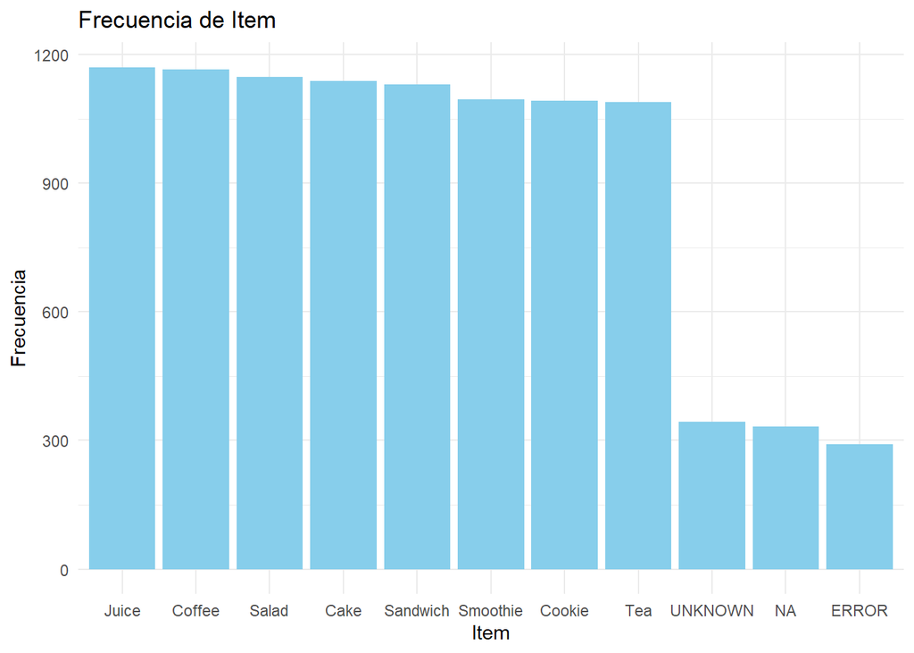

```
## [1] "Resumen de casos especiales"
## [1] "Item"
## # A tibble: 1 × 3
##   NA_count ERROR_count UNKNOWN_count
##      <int>       <int>         <int>
## 1      333         292           344
##
## -------------------------------------------------------
```

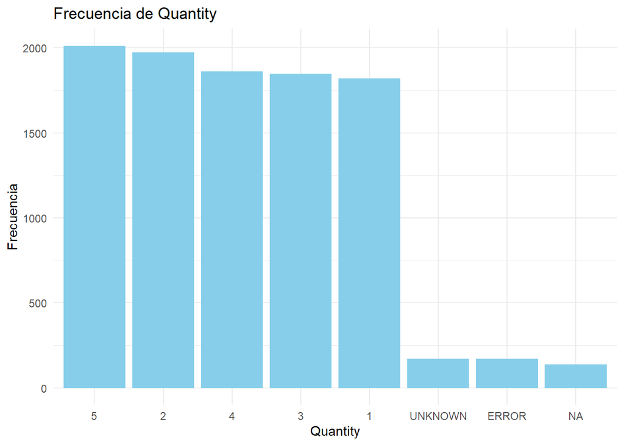

```
## [1] "Resumen de casos especiales"
## [1] "Quantity"
## # A tibble: 1 × 3
##   NA_count ERROR_count UNKNOWN_count
##      <int>       <int>         <int>
## 1      138         170           171
##
## -------------------------------------------------------
```

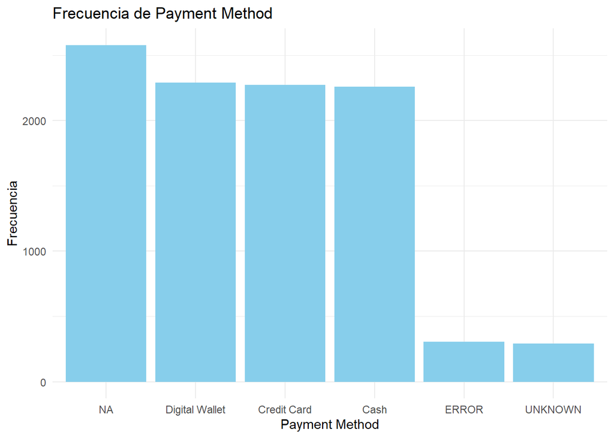

```
## [1] "Resumen de casos especiales"
## [1] "Payment Method"
## # A tibble: 1 × 3
##   NA_count ERROR_count UNKNOWN_count
##      <int>       <int>         <int>
## 1     2579         306           293
##
## -------------------------------------------------------
```

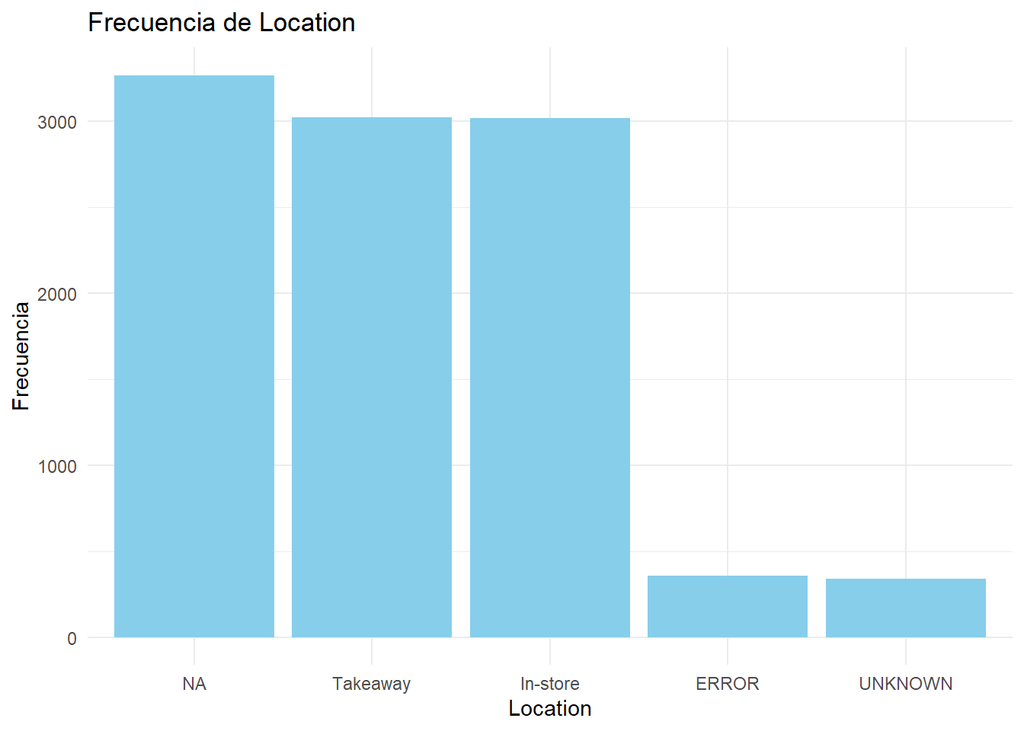

```
## [1] "Resumen de casos especiales"
## [1] "Location"
## # A tibble: 1 × 3
##   NA_count ERROR_count UNKNOWN_count
##      <int>       <int>         <int>
## 1     3265         358           338
##
## -------------------------------------------------------
```

```r
cols <- c("Item", "Quantity", "Payment Method", "Location")
plot_column_summary <- function(df, col_name) {
  df <- df %>% mutate(temp = as.character(.data[[col_name]]))
  freq_table <- df %>%
    mutate(temp = if_else(is.na(temp), "NA", temp)) %>%
    group_by(temp) %>%
    summarize(count = n(), .groups = "drop") %>%
    arrange(desc(count))
  p_bar <- ggplot(freq_table, aes(x = reorder(temp, -count), y = count)) +
    geom_bar(stat = "identity", fill = "skyblue") +
    labs(title = paste("Frecuencia de", col_name),
         x = col_name,
         y = "Frecuencia") +
    theme_minimal()
  print(p_bar)
  special_counts <- df %>%
    summarize(NA_count = sum(is.na(.data[[col_name]])),
              ERROR_count = sum(.data[[col_name]] == "ERROR", na.rm = TRUE),
              UNKNOWN_count = sum(.data[[col_name]] == "UNKNOWN", na.rm = TRUE))
  print("Resumen de casos especiales")
  print(col_name)
  print(special_counts)
  cat("\n-------------------------------------------------------\n")
}
for (col in cols) {
  plot_column_summary(cafe_sales_df, col)
}
```

### Preguntas Específicas

**1. ¿Cuál es el *Item* más frecuente?**  
Se responde directamente: **Juice**

**2. ¿Cuál es la *Quantity* menos frecuente?**  
Se responde: **1**

**3. ¿Cuántas personas pagaron con *cash*?**

Se calcula el total de registros con “Cash” en la columna *Payment Method*:

```r
sum(cafe_sales_df$`Payment Method` == "Cash", na.rm = TRUE)
```

```
## [1] 2258
```

*Respuesta:* 2258

**4. ¿Cuántos registros en *Location* presentan “UNKNOWN”, *NA* o “ERROR”? ¿Qué proporción representan sobre el total de filas?**

Se calcula la cantidad y la proporción:

```r
non_informative_count <- sum(cafe_sales_df$Location %in% c("UNKNOWN", "ERROR"), na.rm = TRUE)
nas_location <- sum(is.na(cafe_sales_df$Location))
print(non_informative_count + nas_location)
```

```
## [1] 3961
```

```r
print((non_informative_count + nas_location) / length(cafe_sales_df$Location))
```

```
## [1] 0.3961
```

*Respuesta:* 3961 registros y el 39.61% del total.

**5. Estadísticas de la columna *Price Per Unit***

Se eliminan los valores no numéricos, y se calcula el promedio, mediana y desviación estándar:

```r
precioxunidad <- as.numeric(cafe_sales_df$`Price Per Unit`)
precioxunidadSinNA <- na.omit(precioxunidad)
promedio <- mean(precioxunidadSinNA, na.rm = TRUE)
mediana <- median(precioxunidadSinNA, na.rm = TRUE)
desvio <- sd(precioxunidadSinNA, na.rm = TRUE)
cat("Promedio:", round(promedio, 2), "\n")
```

```
## Promedio: 2.95
```

```r
cat("Mediana:", round(mediana, 2), "\n")
```

```
## Mediana: 3
```

```r
cat("Desvío Estándar:", round(desvio, 2), "\n")
```

```
## Desvío Estándar: 1.28
```

*Salida:*  
Promedio: 2.95  
Mediana: 3  
Desvío Estándar: 1.28

## 3. Análisis de Outliers y Patrones Temporales

Se examinan posibles outliers en columnas numéricas y se analiza la distribución de las transacciones a lo largo del tiempo.

### Revisión de valores en *Price Per Unit* y *Total Spent*

```r
table(cafe_sales_df$`Price Per Unit`)
```

```
##
##     1.0     1.5     2.0     3.0     4.0     5.0   ERROR UNKNOWN
##    1143    1133    1227    2429    2331    1204     190     164
```

```r
table(cafe_sales_df$`Total Spent`)
```

```
##
##     1.0     1.5    10.0    12.0    15.0    16.0     2.0    20.0    25.0     3.0
##     232     205     524     939     734     444     497     746     259     930
##     4.0     4.5     5.0     6.0     7.5     8.0     9.0   ERROR UNKNOWN
##     923     225     468     979     237     677     479     164     165
```

Se obtiene también el promedio de *Total Spent* para referencia:

```r
mean(as.numeric(cafe_sales_df$`Total Spent`), na.rm = T)
```

```
## [1] 8.924352
```

### Análisis de la columna *Transaction Date*

Se guarda el dataset original para futuras comparaciones y se visualiza el contenido:

```r
cafe_sales_df_original <- cafe_sales_df
cafe_sales_df_original
```

| Transaction ID | Item | Quantity | Price Per Unit | Total Spent | Payment Method | Location | Transaction Date |
| --- | --- | --- | --- | --- | --- | --- | --- |
| TXN_1961373 | Coffee | 2 | 2.0 | 4.0 | Credit Card | Takeaway | 2023-09-08 |
| TXN_4977031 | Cake | 4 | 3.0 | 12.0 | Cash | In-store | 2023-05-16 |
| TXN_4271903 | Cookie | 4 | 1.0 | ERROR | Credit Card | In-store | 2023-07-19 |
| TXN_7034554 | Salad | 2 | 5.0 | 10.0 | UNKNOWN | UNKNOWN | 2023-04-27 |
| TXN_3160411 | Coffee | 2 | 2.0 | 4.0 | Digital Wallet | In-store | 2023-06-11 |
| TXN_2602893 | Smoothie | 5 | 4.0 | 20.0 | Credit Card | NA | 2023-03-31 |
| TXN_4433211 | UNKNOWN | 3 | 3.0 | 9.0 | ERROR | Takeaway | 2023-10-06 |
| TXN_6699534 | Sandwich | 4 | 4.0 | 16.0 | Cash | UNKNOWN | 2023-10-28 |
| TXN_4717867 | NA | 5 | 3.0 | 15.0 | NA | Takeaway | 2023-07-28 |
| TXN_2064365 | Sandwich | 5 | 4.0 | 20.0 | NA | In-store | 2023-12-31 |

[output cut: 9990 more lines]

Se convierten las fechas y se grafica la frecuencia de transacciones por fecha:

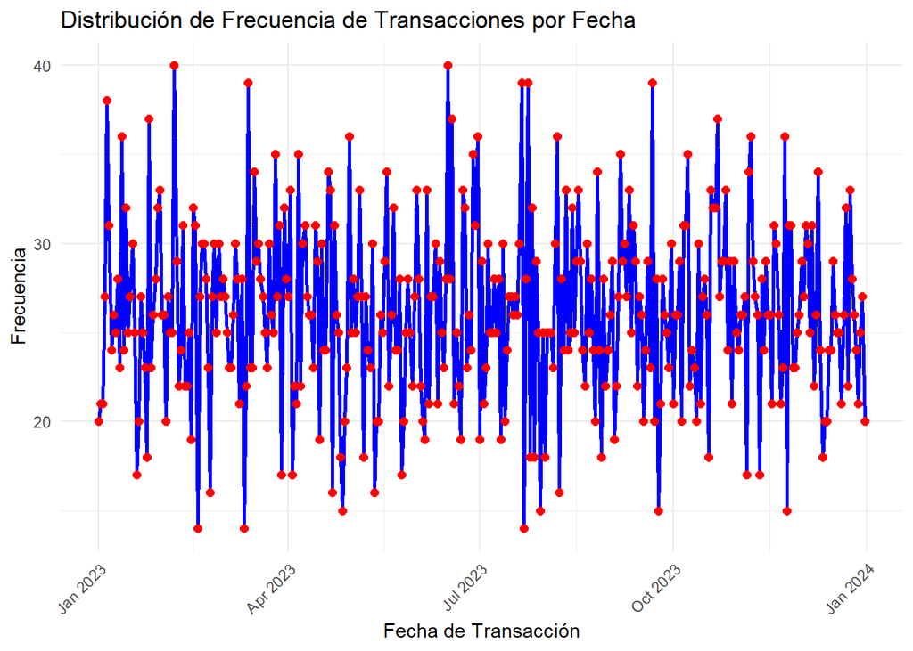

```r
cafe_sales_df <- cafe_sales_df %>%
  mutate(`Transaction Date` = as.Date(`Transaction Date`, format = "%Y-%m-%d")) %>%
  filter(!is.na(`Transaction Date`))
frecuencia_fechas <- cafe_sales_df %>%
  group_by(`Transaction Date`) %>%
  summarise(Frecuencia = n())
ggplot(frecuencia_fechas, aes(x = `Transaction Date`, y = Frecuencia)) +
  geom_line(color = "blue", size = 1) +
  geom_point(color = "red", size = 2) +
  labs(title = "Distribución de Frecuencia de Transacciones por Fecha",
       x = "Fecha de Transacción",
       y = "Frecuencia") +
  theme_minimal() +
  theme(axis.text.x = element_text(angle = 45, hjust = 1))
```

Se muestra el dataset filtrado:

```r
cafe_sales_df
```

| Transaction ID | Item | Quantity | Price Per Unit | Total Spent | Payment Method | Location | Transaction Date |
| --- | --- | --- | --- | --- | --- | --- | --- |
| TXN_1961373 | Coffee | 2 | 2.0 | 4.0 | Credit Card | Takeaway | 2023-09-08 |
| TXN_4977031 | Cake | 4 | 3.0 | 12.0 | Cash | In-store | 2023-05-16 |
| TXN_4271903 | Cookie | 4 | 1.0 | ERROR | Credit Card | In-store | 2023-07-19 |
| TXN_7034554 | Salad | 2 | 5.0 | 10.0 | UNKNOWN | UNKNOWN | 2023-04-27 |
| TXN_3160411 | Coffee | 2 | 2.0 | 4.0 | Digital Wallet | In-store | 2023-06-11 |
| TXN_2602893 | Smoothie | 5 | 4.0 | 20.0 | Credit Card | NA | 2023-03-31 |
| TXN_4433211 | UNKNOWN | 3 | 3.0 | 9.0 | ERROR | Takeaway | 2023-10-06 |
| TXN_6699534 | Sandwich | 4 | 4.0 | 16.0 | Cash | UNKNOWN | 2023-10-28 |
| TXN_4717867 | NA | 5 | 3.0 | 15.0 | NA | Takeaway | 2023-07-28 |
| TXN_2064365 | Sandwich | 5 | 4.0 | 20.0 | NA | In-store | 2023-12-31 |

[output cut: 9530 more lines]

Se concluye que no existen outliers relevantes.

### Análisis de días y meses

Se utilizan funciones para generar nuevas columnas basadas en la fecha, como el día de la semana y el mes de venta. Se configura el orden de días y meses y se generan gráficos de barras.

```r
cafe_sales_df <- cafe_sales_df %>%
  mutate(`Transaction Date` = as.Date(`Transaction Date`, format = "%Y-%m-%d")) %>%
  filter(!is.na(`Transaction Date`))
dias <- c("Domingo", "Lunes", "Martes", "Miércoles", "Jueves", "Viernes", "Sábado")
cafe_sales_df <- cafe_sales_df %>%
  mutate(
    dia_del_año = as.numeric(format(`Transaction Date`, "%j")),
    diaSemana = dias[((dia_del_año - 1) %% 7) + 1]
  )
orden_meses <- c("enero", "febrero", "marzo", "abril", "mayo", "junio",
                 "julio", "agosto", "septiembre", "octubre", "noviembre", "diciembre")
Sys.setlocale("LC_TIME", "es_ES.UTF-8")
```

```
## [1] "es_ES.UTF-8"
```

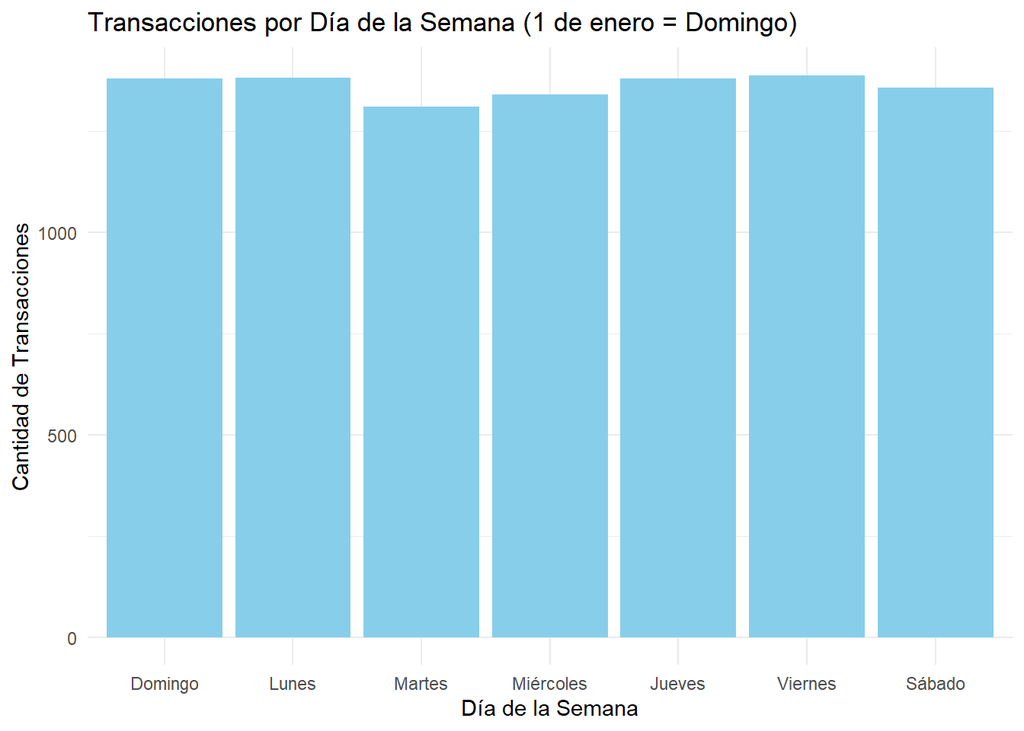

```r
cafe_sales_df <- cafe_sales_df %>%
  mutate(
    mesDeVenta = tolower(format(`Transaction Date`, "%B")),
    mesDeVenta = factor(mesDeVenta, levels = orden_meses, ordered = TRUE)
  )
cafe_sales_df <- cafe_sales_df %>%
  mutate(
    mesDeVenta = tolower(format(`Transaction Date`, "%B")),
    mesDeVenta = factor(mesDeVenta, levels = orden_meses, ordered = TRUE)
  )
orden_dias <- dias
cafe_sales_df <- cafe_sales_df %>%
  mutate(
    diaSemana = factor(diaSemana, levels = orden_dias, ordered = TRUE)
  )
grafico_dias <- ggplot(cafe_sales_df, aes(x = diaSemana)) +
  geom_bar(fill = "skyblue") +
  labs(title = "Transacciones por Día de la Semana (1 de enero = Domingo)",
       x = "Día de la Semana",
       y = "Cantidad de Transacciones") +
  theme_minimal()
print(grafico_dias)
```

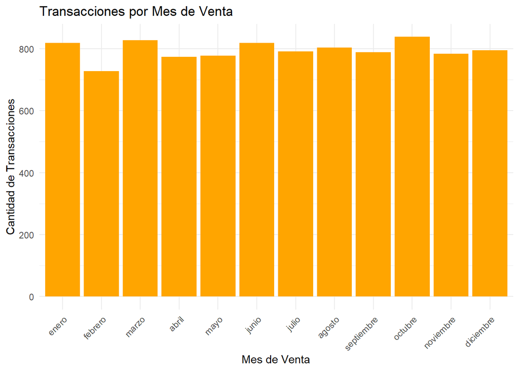

```r
grafico_meses <- ggplot(cafe_sales_df, aes(x = mesDeVenta)) +
  geom_bar(fill = "orange") +
  labs(title = "Transacciones por Mes de Venta",
       x = "Mes de Venta",
       y = "Cantidad de Transacciones") +
  theme_minimal() +
  theme(axis.text.x = element_text(angle = 45, hjust = 1))
print(grafico_meses)
```

#### Preguntas sobre patrones temporales

Conociendo que el 1 de enero de 2023 fue domingo:

- **¿Cuál es el día de la semana con más transacciones y cuál con menos?**

```r
ventas_por_dia <- cafe_sales_df %>%
  group_by(diaSemana) %>%
  summarise(cantidad = n())
dia_max <- ventas_por_dia %>% filter(cantidad == max(cantidad))
dia_min <- ventas_por_dia %>% filter(cantidad == min(cantidad))
print("Día de la semana con más ventas:")
```

```
## [1] "Día de la semana con más ventas:"
```

```r
print(dia_max)
```

```
## # A tibble: 1 × 2
##   diaSemana cantidad
##   <ord>        <int>
## 1 Viernes       1388
```

```r
print("Día de la semana con menos filas:")
```

```
## [1] "Día de la semana con menos filas:"
```

```r
print(dia_min)
```

```
## # A tibble: 1 × 2
##   diaSemana cantidad
##   <ord>        <int>
## 1 Martes        1311
```

*Respuesta (según los resultados):*  
- Día con menos transacciones: Martes (1311 registros)  
- Día con más transacciones: Viernes (1388 registros)

- **¿Cuál es el mes con más y con menos transacciones?**

```r
ventas_por_mes <- cafe_sales_df %>%
  group_by(mesDeVenta) %>%
  summarise(cantidad = n())
mes_max <- ventas_por_mes %>% filter(cantidad == max(cantidad))
mes_min <- ventas_por_mes %>% filter(cantidad == min(cantidad))
print("Mes con más transacciones:")
```

```
## [1] "Mes con más transacciones:"
```

```r
print(mes_max)
```

```
## # A tibble: 1 × 2
##   mesDeVenta cantidad
##   <ord>         <int>
## 1 octubre         838
```

```r
print("Mes con menos transacciones:")
```

```
## [1] "Mes con menos transacciones:"
```

```r
print(mes_min)
```

```
## # A tibble: 1 × 2
##   mesDeVenta cantidad
##   <ord>         <int>
## 1 febrero         727
```

*Respuesta (según los resultados):*  
- Mes con menos transacciones: febrero (727 registros)  
- Mes con más transacciones: octubre (838 registros)

## 4. Completar y Corregir Datos

Se realizan comprobaciones de consistencia en la columna *Price Per Unit* y se crea un diccionario de precios para cada *Item*. Luego se corrigen datos faltantes en *Quantity*, *Price Per Unit* y *Total Spent* según la relación
$$\texttt{Quantity} \times \texttt{Price Per
Unit} = \texttt{Total Spent}$$

### Verificación de consistencia y creación del diccionario

```r
cafe_sales_df <- cafe_sales_df_original
cafe_sales_df$`Price Per Unit` <- as.numeric(cafe_sales_df$`Price Per Unit`)
df_filtrado <- cafe_sales_df %>%
  filter(!Item %in% c("ERROR", "UNKNOWN", NA))
consistencia <- df_filtrado %>%
  group_by(Item) %>%
  summarise(n_precios = n_distinct(`Price Per Unit`, na.rm = TRUE))
print(consistencia)
```

```
## # A tibble: 8 × 2
##   Item     n_precios
##   <chr>        <int>
## 1 Cake             1
## 2 Coffee           1
## 3 Cookie           1
## 4 Juice            1
## 5 Salad            1
## 6 Sandwich         1
## 7 Smoothie         1
## 8 Tea              1
```

```r
todos_consistentes <- all(consistencia$n_precios == 1)
if (todos_consistentes) {
  print("Todos los items tienen un precio unitario consistente.")
  dict_precios <- cafe_sales_df %>%
    group_by(Item) %>%
    summarise(precio = first(na.omit(`Price Per Unit`))) %>%
    deframe()
  print(dict_precios)
} else {
  print("No todos los items tienen un precio unitario consistente.")
}
```

```
## [1] "Todos los items tienen un precio unitario consistente."
##     Cake   Coffee   Cookie    ERROR    Juice    Salad Sandwich Smoothie
##      3.0      2.0      1.0      1.5      3.0      5.0      4.0      4.0
##      Tea  UNKNOWN     <NA>
##      1.5      3.0      3.0
```

Se revisa el precio unitario para el *Item* “Coffee”:

```r
table(cafe_sales_df[cafe_sales_df$Item == "Coffee", ]$`Price Per Unit`)
```

```
##
##    2
## 1108
```

### Actualización de *Price Per Unit* basándose en un menú predefinido

El menú es el siguiente: Cake: 3, Juice: 3, Coffee: 2, Cookie: 1, Salad: 5, Sandwich: 4, Smoothie: 4, Tea: 2.

```r
library(dplyr)
menu <- c("Cake" = 3, "Juice" = 3, "Coffee" = 2, "Cookie" = 1, "Salad" = 5, "Sandwich" = 4, "Smoothie" = 4, "Tea" = 2)
cafe_sales_df$`Price Per Unit` <- as.numeric(cafe_sales_df$`Price Per Unit`)
cafe_sales_df <- cafe_sales_df %>%
  mutate(`Price Per Unit` = if_else(
    is.na(`Price Per Unit`) & !is.na(Item) & !(Item %in% c("ERROR", "UNKNOWN")),
    as.numeric(menu[Item]),
    `Price Per Unit`
  ))
print(cafe_sales_df)
```

```
## # A tibble: 10,000 × 8
##    `Transaction ID` Item     Quantity `Price Per Unit` `Total Spent`
##    <chr>            <chr>    <chr>               <dbl> <chr>
##  1 TXN_1961373      Coffee   2                       2 4.0
##  2 TXN_4977031      Cake     4                       3 12.0
##  3 TXN_4271903      Cookie   4                       1 ERROR
##  4 TXN_7034554      Salad    2                       5 10.0
##  5 TXN_3160411      Coffee   2                       2 4.0
##  6 TXN_2602893      Smoothie 5                       4 20.0
##  7 TXN_4433211      UNKNOWN  3                       3 9.0
##  8 TXN_6699534      Sandwich 4                       4 16.0
##  9 TXN_4717867      <NA>     5                       3 15.0
## 10 TXN_2064365      Sandwich 5                       4 20.0
## # ℹ 9,990 more rows
## # ℹ 3 more variables: `Payment Method` <chr>, Location <chr>,
## #   `Transaction Date` <chr>
```

### Completado de valores faltantes en *Quantity*, *Price Per Unit* y *Total Spent*

Se convierten las columnas a numérico y se rellenan los valores faltantes según la relación indicada:

```r
cafe_sales_df <- cafe_sales_df %>%
  mutate(
    Quantity = as.numeric(Quantity),
    `Price Per Unit` = as.numeric(`Price Per Unit`),
    `Total Spent` = as.numeric(`Total Spent`)
  )
cafe_sales_df <- cafe_sales_df %>%
  mutate(
    Quantity = if_else(
      is.na(Quantity) & !is.na(`Price Per Unit`) & !is.na(`Total Spent`),
      `Total Spent` / `Price Per Unit`,
      Quantity
    ),
    `Price Per Unit` = if_else(
      is.na(`Price Per Unit`) & !is.na(Quantity) & !is.na(`Total Spent`),
      `Total Spent` / Quantity,
      `Price Per Unit`
    ),
    `Total Spent` = if_else(
      is.na(`Total Spent`) & !is.na(Quantity) & !is.na(`Price Per Unit`),
      Quantity * `Price Per Unit`,
      `Total Spent`
    )
  )
print(cafe_sales_df)
```

```
## # A tibble: 10,000 × 8
##    `Transaction ID` Item     Quantity `Price Per Unit` `Total Spent`
##    <chr>            <chr>       <dbl>            <dbl>         <dbl>
##  1 TXN_1961373      Coffee          2                2             4
##  2 TXN_4977031      Cake            4                3            12
##  3 TXN_4271903      Cookie          4                1             4
##  4 TXN_7034554      Salad           2                5            10
##  5 TXN_3160411      Coffee          2                2             4
##  6 TXN_2602893      Smoothie        5                4            20
##  7 TXN_4433211      UNKNOWN         3                3             9
##  8 TXN_6699534      Sandwich        4                4            16
##  9 TXN_4717867      <NA>            5                3            15
## 10 TXN_2064365      Sandwich        5                4            20
## # ℹ 9,990 more rows
## # ℹ 3 more variables: `Payment Method` <chr>, Location <chr>,
## #   `Transaction Date` <chr>
```

### Corrección de la columna *Item* basándose en *Price Per Unit*

Si el valor de *Price Per Unit* es 3 se asume “Cake” y si es 4 se asume “Sandwich”. Se utiliza un diccionario inverso para realizar la asignación:

```r
price_to_item <- c("1" = "Cookie", "2" = "Coffee", "3" = "Cake", "4" = "Sandwich", "5" = "Salad")
cafe_sales_df <- cafe_sales_df %>%
  mutate(
    Item = if_else(
      (is.na(Item) | Item %in% c("ERROR", "UNKNOWN")) & !is.na(`Price Per Unit`),
      price_to_item[as.character(`Price Per Unit`)],
      Item
    )
  )
print(cafe_sales_df)
```

```
## # A tibble: 10,000 × 8
##    `Transaction ID` Item     Quantity `Price Per Unit` `Total Spent`
##    <chr>            <chr>       <dbl>            <dbl>         <dbl>
##  1 TXN_1961373      Coffee          2                2             4
##  2 TXN_4977031      Cake            4                3            12
##  3 TXN_4271903      Cookie          4                1             4
##  4 TXN_7034554      Salad           2                5            10
##  5 TXN_3160411      Coffee          2                2             4
##  6 TXN_2602893      Smoothie        5                4            20
##  7 TXN_4433211      Cake            3                3             9
##  8 TXN_6699534      Sandwich        4                4            16
##  9 TXN_4717867      Cake            5                3            15
## 10 TXN_2064365      Sandwich        5                4            20
## # ℹ 9,990 more rows
## # ℹ 3 more variables: `Payment Method` <chr>, Location <chr>,
## #   `Transaction Date` <chr>
```

### Verificación de valores no informativos

Se cuenta la cantidad de *NA*, “ERROR” y “UNKNOWN” en cada columna para confirmar que la limpieza es correcta:

```r
na_counts <- sapply(cafe_sales_df, function(x) sum(is.na(x)))
error_counts <- sapply(cafe_sales_df, function(x) sum(as.character(x) == "ERROR", na.rm = TRUE))
unknown_counts <- sapply(cafe_sales_df, function(x) sum(as.character(x) == "UNKNOWN", na.rm = TRUE))
result_matrix <- rbind("NA" = na_counts, "ERROR" = error_counts, "UNKNOWN" = unknown_counts)
print(result_matrix)
```

```
##         Transaction ID Item Quantity Price Per Unit Total Spent Payment Method
## NA                   0  120       23              6          23           2579
## ERROR                0    2        0              0           0            306
## UNKNOWN              0    2        0              0           0            293
##         Location Transaction Date
## NA          3265              159
## ERROR        358              142
## UNKNOWN      338              159
```

Se muestra el dataset actualizado:

```r
cafe_sales_df
```

| Transaction ID | Item | Quantity | Price Per Unit | Total Spent | Payment Method | Location | Transaction Date |
| --- | --- | --- | --- | --- | --- | --- | --- |
| TXN_1961373 | Coffee | 2.00 | 2.0 | 4.0 | Credit Card | Takeaway | 2023-09-08 |
| TXN_4977031 | Cake | 4.00 | 3.0 | 12.0 | Cash | In-store | 2023-05-16 |
| TXN_4271903 | Cookie | 4.00 | 1.0 | 4.0 | Credit Card | In-store | 2023-07-19 |
| TXN_7034554 | Salad | 2.00 | 5.0 | 10.0 | UNKNOWN | UNKNOWN | 2023-04-27 |
| TXN_3160411 | Coffee | 2.00 | 2.0 | 4.0 | Digital Wallet | In-store | 2023-06-11 |
| TXN_2602893 | Smoothie | 5.00 | 4.0 | 20.0 | Credit Card | NA | 2023-03-31 |
| TXN_4433211 | Cake | 3.00 | 3.0 | 9.0 | ERROR | Takeaway | 2023-10-06 |
| TXN_6699534 | Sandwich | 4.00 | 4.0 | 16.0 | Cash | UNKNOWN | 2023-10-28 |
| TXN_4717867 | Cake | 5.00 | 3.0 | 15.0 | NA | Takeaway | 2023-07-28 |
| TXN_2064365 | Sandwich | 5.00 | 4.0 | 20.0 | NA | In-store | 2023-12-31 |

[output cut: 9990 more lines]

### Relleno de valores faltantes mediante la moda

Se definen funciones para calcular la moda (excluyendo *NA*, “ERROR” y “UNKNOWN”) y se reemplazan estos valores en las columnas *Item*, *Quantity*, *Price Per Unit*, *Total Spent*, *Payment Method*, *Location* y *Transaction Date*.

```r
library(dplyr)
cols_a_rellenar <- c("Item", "Quantity", "Price Per Unit", "Total Spent",
                       "Payment Method", "Location", "Transaction Date")
calcular_moda <- function(x) {
  x_char <- as.character(x)
  validos <- x_char[!is.na(x_char) & !(x_char %in% c("ERROR", "UNKNOWN"))]
  if (length(validos) == 0) return(NA)
  tab <- table(validos)
  moda <- names(tab)[which.max(tab)]
  return(moda)
}
reemplazar_con_moda <- function(x, moda) {
  if (is.na(moda)) return(x)
  if (is.numeric(x)) {
    moda_num <- as.numeric(moda)
    x[is.na(x) | x %in% c("ERROR", "UNKNOWN")] <- moda_num
  } else {
    x <- as.character(x)
    x[is.na(x) | x %in% c("ERROR", "UNKNOWN")] <- moda
  }
  return(x)
}
modas <- sapply(cafe_sales_df[cols_a_rellenar], calcular_moda)
for (col in cols_a_rellenar) {
  moda <- modas[[col]]
  cafe_sales_df[[col]] <- reemplazar_con_moda(cafe_sales_df[[col]], moda)
}
print(cafe_sales_df)
```

```
## # A tibble: 10,000 × 8
##    `Transaction ID` Item     Quantity `Price Per Unit` `Total Spent`
##    <chr>            <chr>       <dbl>            <dbl>         <dbl>
##  1 TXN_1961373      Coffee          2                2             4
##  2 TXN_4977031      Cake            4                3            12
##  3 TXN_4271903      Cookie          4                1             4
##  4 TXN_7034554      Salad           2                5            10
##  5 TXN_3160411      Coffee          2                2             4
##  6 TXN_2602893      Smoothie        5                4            20
##  7 TXN_4433211      Cake            3                3             9
##  8 TXN_6699534      Sandwich        4                4            16
##  9 TXN_4717867      Cake            5                3            15
## 10 TXN_2064365      Sandwich        5                4            20
## # ℹ 9,990 more rows
## # ℹ 3 more variables: `Payment Method` <chr>, Location <chr>,
## #   `Transaction Date` <chr>
```

Se vuelve a verificar la cantidad de valores no informativos:

```r
na_counts <- sapply(cafe_sales_df, function(x) sum(is.na(x)))
error_counts <- sapply(cafe_sales_df, function(x) sum(as.character(x) == "ERROR", na.rm = TRUE))
unknown_counts <- sapply(cafe_sales_df, function(x) sum(as.character(x) == "UNKNOWN", na.rm = TRUE))
result_matrix <- rbind("NA" = na_counts, "ERROR" = error_counts, "UNKNOWN" = unknown_counts)
print(result_matrix)
```

```
##         Transaction ID Item Quantity Price Per Unit Total Spent Payment Method
## NA                   0    0        0              0           0              0
## ERROR                0    0        0              0           0              0
## UNKNOWN              0    0        0              0           0              0
##         Location Transaction Date
## NA             0                0
## ERROR          0                0
## UNKNOWN        0                0
```

## 5. Análisis con Bootstrapping y Visualización

Utilizando el dataset corregido, se realizan resampleos mediante bootstrapping, se divide el dataset en tres bloques y se generan visualizaciones adicionales.

### a) Bootstrapping de la media de *Total Spent*

Se establece la semilla, se realizan 1000 resampleos y se grafica la distribución de la media:

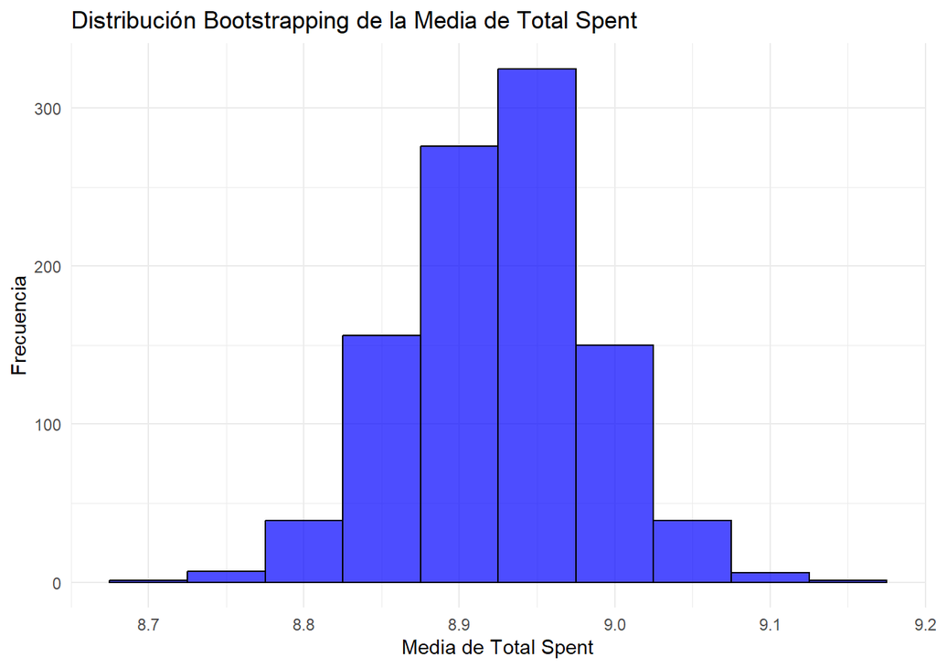

```r
set.seed(123)
n_bootstrap <- 1000
bootstrap_means <- replicate(n_bootstrap, {
  muestra <- sample(cafe_sales_df$`Total Spent`, size = nrow(cafe_sales_df), replace = TRUE)
  mean(muestra)
})
bootstrap_df <- data.frame(MeanTotalSpent = bootstrap_means)
library(ggplot2)
p1 <- ggplot(bootstrap_df, aes(x = MeanTotalSpent)) +
  geom_histogram(binwidth = 0.05, fill = "blue", color = "black", alpha = 0.7) +
  labs(title = "Distribución Bootstrapping de la Media de Total Spent",
       x = "Media de Total Spent", y = "Frecuencia") +
  theme_minimal()
print(p1)
```

### b) División del dataset en tres bloques

Se barajan las filas y se dividen en tres bloques de 8000, 1000 y 1000 registros (si el dataset tiene al menos 10,000 filas). Se calculan estadísticas descriptivas de *Total Spent* para cada bloque.

```r
cafe_sales_df_shuffled <- cafe_sales_df[sample(nrow(cafe_sales_df)), ]
n_total <- nrow(cafe_sales_df_shuffled)
if(n_total >= 10000) {
  block1 <- cafe_sales_df_shuffled[1:8000, ]
  block2 <- cafe_sales_df_shuffled[8001:9000, ]
  block3 <- cafe_sales_df_shuffled[9001:10000, ]
  stats <- data.frame(
    Bloque = c("Block1", "Block2", "Block3"),
    Media = c(mean(block1$`Total Spent`),
              mean(block2$`Total Spent`),
              mean(block3$`Total Spent`)),
    Mediana = c(median(block1$`Total Spent`),
                median(block2$`Total Spent`),
                median(block3$`Total Spent`)),
    SD = c(sd(block1$`Total Spent`),
           sd(block2$`Total Spent`),
           sd(block3$`Total Spent`))
  )
  print(stats)
} else {
  message("El dataset no tiene al menos 10000 filas, no es posible realizar la división en bloques.")
}
```

```
##   Bloque    Media Mediana       SD
## 1 Block1 8.875438       8 5.985424
## 2 Block2 9.084000       8 6.084815
## 3 Block3 9.149500       8 6.023262
```

### c) Visualización adicional

Como ejemplo se genera un boxplot de *Total Spent* según el método de pago:

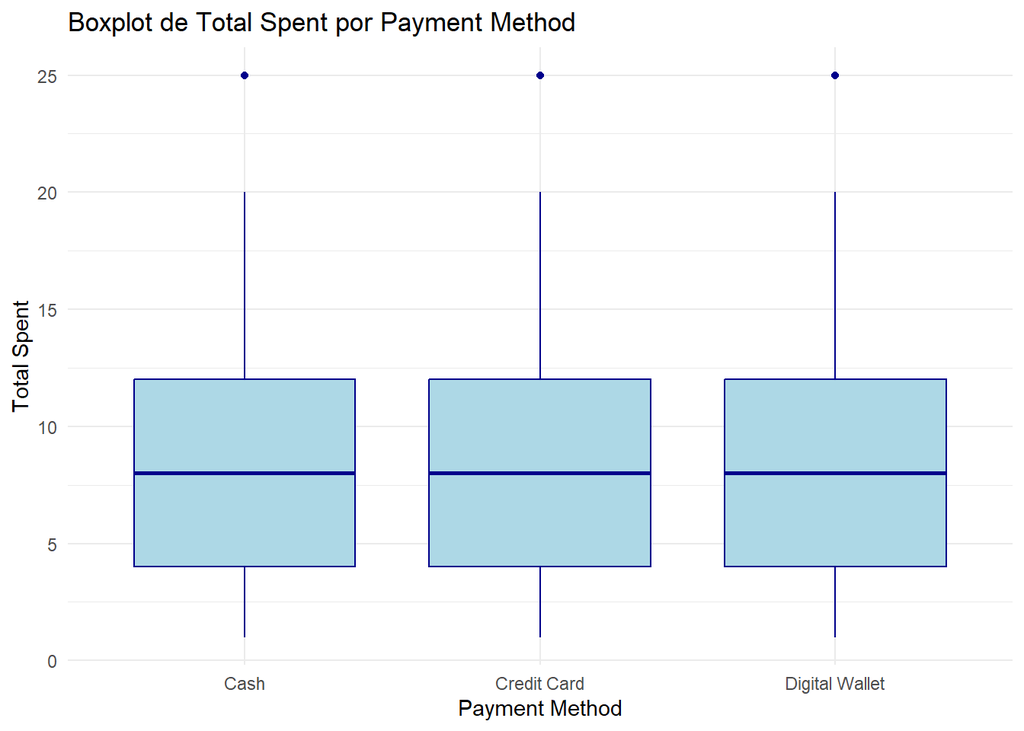

```r
p2 <- ggplot(cafe_sales_df, aes(x = `Payment Method`, y = `Total Spent`)) +
  geom_boxplot(fill = "lightblue", color = "darkblue") +
  labs(title = "Boxplot de Total Spent por Payment Method",
       x = "Payment Method", y = "Total Spent") +
  theme_minimal()
print(p2)
```